# Citizen Complaints and Regulatory Response Speed

STA 9750 | Individual Report | Restaurant Complaints vs Inspection Risk in NYC

Author

Kiran Narsipur

Published

May 12, 2026

## Overarching Question and My Contribution

This report is one of five individual analyses contributing to the team project *Restaurant Complaints vs Inspection Risk in NYC*. The project’s overarching question asks whether neighborhoods with higher complaint activity experience systematically worse restaurant inspection outcomes. The preceding four analyses establish that the answer is yes: high-complaint neighborhoods show more repeat critical violations, worse inspection scores, and no evidence that complaints lead violations temporally, with Food Establishment complaints being the strongest individual signal. My contribution addresses a fundamentally different dimension of the relationship between complaints and inspections: does filing a complaint actually change what the regulatory system does?

The analyses conducted by my teammates establish associations between complaint volume and inspection outcomes, but associations alone cannot tell us whether complaints are an active input into the regulatory process or merely a passive reflection of the same conditions that independently drive inspection outcomes. If complaints are purely passive mirrors of food safety conditions, improving the complaint system would not improve food safety enforcement. But if complaints actively cause inspectors to visit establishments sooner than they otherwise would, then 311 is functioning as a direct channel through which citizen engagement shapes government action. This distinction has enormous practical importance: an active channel can be strengthened, publicized, and targeted to improve enforcement efficiency and equity, while a passive mirror cannot.

My specific question is whether food-related 311 complaints lead to inspections, and if so, how much faster do post-complaint inspections arrive compared to the baseline inspection cycle that would occur in the absence of any complaint? I test this by matching each food-related 311 complaint to the next inspection occurring in the same ZIP code within 180 days, and comparing the resulting time-to-inspection distribution against the baseline distribution of gaps between consecutive inspections. If complaints are actively accelerating inspection timelines, the post-complaint distribution should be shifted substantially to the left relative to the baseline distribution.

This analysis is the most mechanistic of the five team reports. Where the other four analyses establish that complaints and outcomes are associated and characterize the nature of that association, this analysis tests for a specific causal mechanism: the acceleration of regulatory response. Finding strong evidence of acceleration would not only confirm that 311 is an active regulatory input but would also provide a partial explanation for the cross-sectional associations documented by my teammates, since more frequent inspections in high-complaint areas would naturally produce more opportunities to identify and record violations.

Published web version: https://carmine-montaperto.github.io/STA9750-2026-SPRING/individual_report.html

## Setup

This section loads required packages and defines the plotting theme used throughout the report. All analytical code and output-producing logic are left unchanged from the submitted version.

```r
pkgs <- c("tidyverse", "lubridate", "scales", "knitr",
          "kableExtra", "broom", "glue", "httr2", "jsonlite")
options(repos = c(CRAN = "https://cloud.r-project.org"))
to_install <- pkgs[!pkgs %in% rownames(installed.packages())]
if (length(to_install) > 0) install.packages(to_install)

library(tidyverse)
library(lubridate)
library(scales)
library(knitr)
library(kableExtra)
library(broom)
library(glue)
library(httr2)
library(jsonlite)
```

```r
theme_nyc <- function() {
  theme_minimal(base_size = 13) +
    theme(plot.title = element_text(face = "bold", size = 15),
          plot.subtitle = element_text(color = "grey40", size = 12),
          plot.caption = element_text(color = "grey55", size = 9),
          axis.title = element_text(size = 11),
          panel.grid.minor = element_blank())
}
```

## Data Acquisition

The analysis uses two NYC Open Data sources: 1. DOHMH restaurant inspections (`43nn-pn8j`) 2. NYC 311 service requests (`erm2-nwe9`)

To improve reproducibility and reduce API load, raw pulls are cached locally as `.rds` files and re-used on subsequent renders when available.

```r
fetch_all_socrata <- function(dataset_id, query = "",
                               select = NULL, page_size = 50000) {
  base_url <- glue("https://data.cityofnewyork.us/resource/{dataset_id}.json")
  offset <- 0; pages <- list()
  repeat {
    req <- request(base_url) |>
      req_url_query(`$limit` = page_size, `$offset` = offset, `$where` = query)
    if (!is.null(select)) req <- req |> req_url_query(`$select` = select)
    page <- req |> req_retry(max_tries = 3) |> req_perform() |>
      resp_body_json(simplifyVector = TRUE) |> as_tibble()
    if (nrow(page) == 0) break
    message(glue("  {dataset_id}: {offset + nrow(page)} rows"))
    pages[[length(pages) + 1]] <- page
    if (nrow(page) < page_size) break
    offset <- offset + page_size
  }
  bind_rows(pages)
}
```

```r
dir.create("data", showWarnings = FALSE)

if (!file.exists("data/raw_inspections.rds")) {
  raw_inspections <- fetch_all_socrata(
    "43nn-pn8j", query = "inspection_date >= '2022-01-01T00:00:00'",
    select = "camis,dba,boro,zipcode,inspection_date,critical_flag"
  )
  saveRDS(raw_inspections, "data/raw_inspections.rds")
} else { raw_inspections <- readRDS("data/raw_inspections.rds") }

if (!file.exists("data/raw_311.rds")) {
  raw_311 <- fetch_all_socrata(
    "erm2-nwe9",
    query = paste("complaint_type IN ('Food Establishment','Food Poisoning',",
                  "'Rodent','Unsanitary Condition')",
                  "AND created_date >= '2022-01-01T00:00:00'"),
    select = "unique_key,complaint_type,created_date,borough,incident_zip"
  )
  saveRDS(raw_311, "data/raw_311.rds")
} else { raw_311 <- readRDS("data/raw_311.rds") }
```

## Data Cleaning

Cleaning steps standardize dates, borough labels, and ZIP codes across both datasets, then restrict records to NYC boroughs and years 2022 onward. These harmonization steps are necessary to make inspection-complaint matching valid at the chosen geographic level.

```r
# For this analysis, only inspection date and ZIP code are needed
# from the inspection dataset. CAMIS is used to compute baseline
# gaps between consecutive inspections at the restaurant level.
inspections <- raw_inspections |>
  mutate(
    inspection_date = as_date(inspection_date),
    borough         = str_to_upper(str_trim(boro)),
    zipcode         = str_pad(str_extract(zipcode, "\\d{5}"), 5, "left", "0"),
    year            = year(inspection_date),
    camis           = as.character(camis)
  ) |>
  filter(!is.na(inspection_date), year >= 2022,
         borough %in% c("BRONX","BROOKLYN","MANHATTAN",
                        "QUEENS","STATEN ISLAND"),
         !is.na(zipcode), zipcode != "00000")

complaints <- raw_311 |>
  mutate(
    date           = as_date(created_date),
    year           = year(date),
    borough        = str_to_upper(str_trim(borough)),
    zipcode        = str_pad(str_extract(incident_zip, "\\d{5}"), 5, "left", "0"),
    complaint_type = str_trim(complaint_type)
  ) |>
  filter(!is.na(date), year >= 2022,
         borough %in% c("BRONX","BROOKLYN","MANHATTAN",
                        "QUEENS","STATEN ISLAND"),
         !is.na(zipcode), zipcode != "00000")

rm(raw_inspections, raw_311); gc()
```

```
          used (Mb) gc trigger  (Mb) max used  (Mb)
Ncells 1787953 95.5    3427607 183.1  2491140 133.1
Vcells 7979335 60.9   18787455 143.4 18614655 142.1
```

```r
cat("Clean inspections:", nrow(inspections),
    "| Clean complaints:", nrow(complaints), "\n")
```

```
Clean inspections: 285749 | Clean complaints: 227409
```

## Data Quality Assessment

First, this analysis uses ZIP code as the geographic unit for matching complaints to inspections. A complaint filed at a specific restaurant is matched to any inspection occurring in the same ZIP code within 180 days, regardless of whether that inspection was at the specific restaurant that generated the complaint. This geographic imprecision means that some matched inspection-complaint pairs may be coincidental: an inspection that was already scheduled at a nearby restaurant may be matched to a complaint that had no role in triggering it. This coincidental matching would dilute the true complaint-triggered inspection signal by introducing non-triggered inspections into the post-complaint distribution. Because this dilution would bias the post-complaint median time toward the baseline rather than away from it, the true acceleration effect at the restaurant address level is likely larger than what we measure here. Our estimates should be interpreted as conservative lower bounds on the true regulatory response speed.

Taken together, these limitations do not invalidate the design, but they do shape interpretation. The estimates should be read as evidence of strong response acceleration at the ZIP level, with likely attenuation relative to restaurant-level causal effects.

## Exploratory Data Analysis

```r
# Compute the baseline inspection gap distribution first.
# The upper bound of 730 days (two years) excludes restaurants
# that closed and reopened, which would produce spuriously large gaps.
baseline_gaps <- inspections |>
  arrange(camis, inspection_date) |>
  group_by(camis) |>
  mutate(prev_inspection = lag(inspection_date),
         days_gap        = as.numeric(inspection_date - prev_inspection)) |>
  filter(!is.na(days_gap), days_gap > 1, days_gap < 730) |>
  ungroup()

baseline_median <- median(baseline_gaps$days_gap, na.rm = TRUE)
baseline_mean   <- mean(baseline_gaps$days_gap,   na.rm = TRUE)

cat("Baseline median gap:", round(baseline_median), "days\n")
```

```
Baseline median gap: 314 days
```

```r
cat("Baseline mean gap:",   round(baseline_mean),   "days\n")
```

```
Baseline mean gap: 303 days
```

```r
cat("Number of consecutive inspection pairs:",
    nrow(baseline_gaps), "\n")
```

```
Number of consecutive inspection pairs: 54224
```

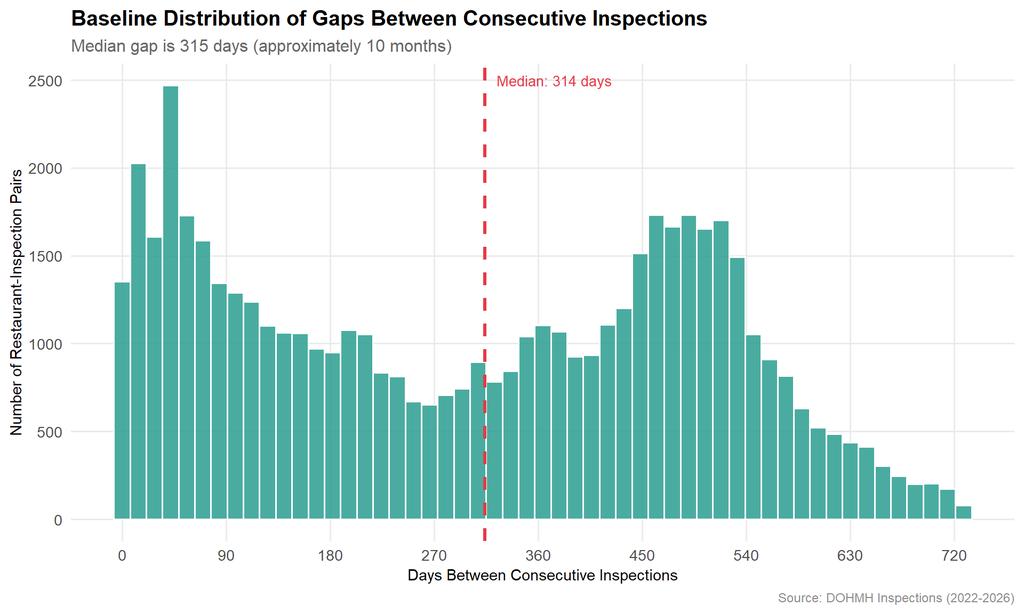

```r
ggplot(baseline_gaps, aes(x = days_gap)) +
  geom_histogram(binwidth = 14, fill = "#2A9D8F",
                 color = "white", alpha = 0.85) +
  geom_vline(xintercept = baseline_median, color = "#E63946",
             linewidth = 1.2, linetype = "dashed") +
  annotate("text", x = baseline_median + 10, y = Inf, vjust = 2,
           hjust = 0, color = "#E63946", size = 3.5,
           label = paste0("Median: ", round(baseline_median), " days")) +
  scale_x_continuous(breaks = seq(0, 730, 90)) +
  labs(title = "Baseline Distribution of Gaps Between Consecutive Inspections",
       subtitle = "Median gap is 315 days (approximately 10 months)",
       x = "Days Between Consecutive Inspections",
       y = "Number of Restaurant-Inspection Pairs",
       caption = "Source: DOHMH Inspections (2022-2026)") +
  theme_nyc()
```

```r
rm(baseline_gaps); gc()
```

```
          used  (Mb) gc trigger  (Mb) max used  (Mb)
Ncells 2038486 108.9    3427607 183.1  3427607 183.1
Vcells 8982672  68.6   18787455 143.4 18614655 142.1
```

This benchmark anchors the rest of the analysis: complaint-response timing is evaluated relative to observed inspection cadence, not an arbitrary threshold.

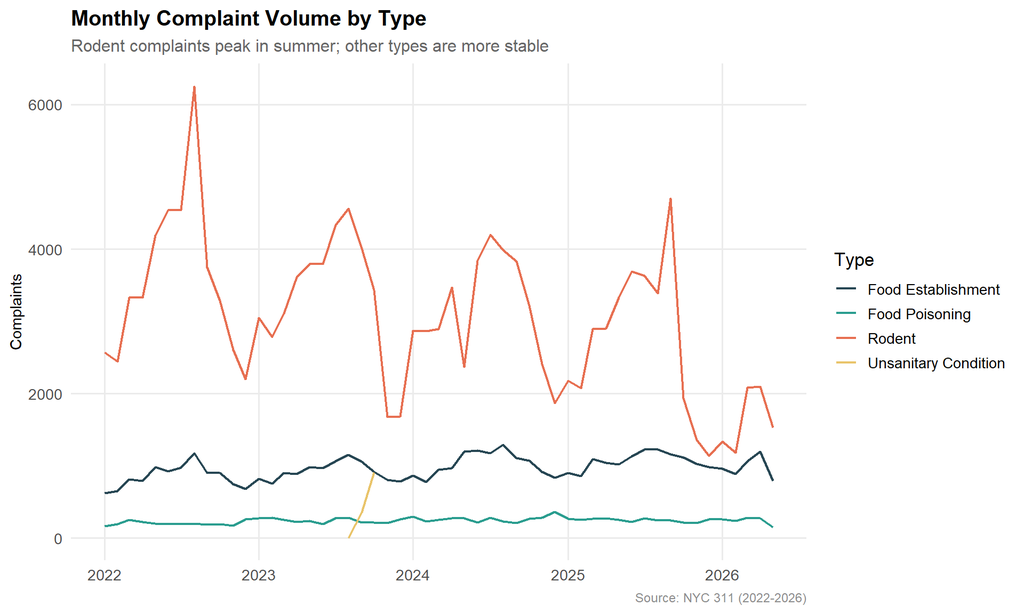

```r
# Monthly complaint volume to understand temporal distribution
# before the matching analysis
complaints |>
  count(complaint_type, month = floor_date(date, "month")) |>
  ggplot(aes(x = month, y = n, color = complaint_type)) +
  geom_line(linewidth = 0.8) +
  scale_color_manual(values = c(
    "Rodent" = "#E76F51", "Food Establishment" = "#264653",
    "Food Poisoning" = "#2A9D8F", "Unsanitary Condition" = "#E9C46A"
  )) +
  labs(title = "Monthly Complaint Volume by Type",
       subtitle = "Rodent complaints peak in summer; other types are more stable",
       x = NULL, y = "Complaints", color = "Type",
       caption = "Source: NYC 311 (2022-2026)") +
  theme_nyc()
```

## Analysis

### Matching Complaints to Subsequent Inspections

```r
# Load pre-computed matches if available; otherwise compute fresh.
# The many-to-many join of 225k complaints by 285k inspections is
# memory-intensive. A random sample of 20k complaints is used if
# pre-computed matches are not available, which is sufficient for
# reliable median and distributional estimates.
if (file.exists("data/sq5_matched.rds")) {
  sq5_matched <- readRDS("data/sq5_matched.rds")
  message("Loaded pre-computed matches: ", nrow(sq5_matched), " pairs")
} else {
  complaints_zip <- complaints |>
    select(unique_key, complaint_type, date, zipcode)

  inspections_zip <- inspections |>
    select(camis, zipcode, inspection_date) |>
    distinct()

  set.seed(42)
  complaints_sample <- complaints_zip |>
    slice_sample(n = min(20000, nrow(complaints_zip)))

  # Match each complaint to the earliest inspection in same ZIP
  # within 180 days after the complaint date
  sq5_matched <- complaints_sample |>
    inner_join(inspections_zip, by = "zipcode",
               relationship = "many-to-many") |>
    filter(inspection_date > date,
           as.numeric(inspection_date - date) <= 180) |>
    mutate(days_to_inspection = as.numeric(inspection_date - date)) |>
    group_by(unique_key) |>
    slice_min(days_to_inspection, n = 1, with_ties = FALSE) |>
    ungroup()

  saveRDS(sq5_matched, "data/sq5_matched.rds")
}

post_complaint_median <- median(sq5_matched$days_to_inspection, na.rm = TRUE)

cat("Matched pairs:", nrow(sq5_matched), "\n")
```

```
Matched pairs: 19872
```

```r
cat("Post-complaint median:", round(post_complaint_median), "days\n")
```

```
Post-complaint median: 4 days
```

```r
cat("Baseline median:", round(315), "days\n")
```

```
Baseline median: 315 days
```

```r
cat("Difference:", round(315 - post_complaint_median), "days faster\n")
```

```
Difference: 311 days faster
```

### Time-to-Inspection Distribution

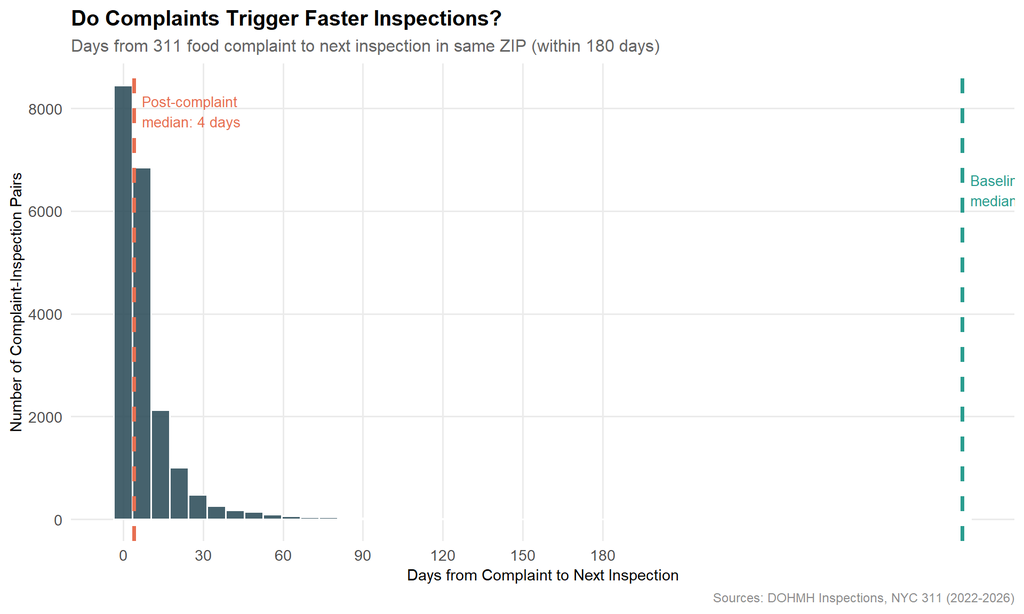

```r
ggplot(sq5_matched, aes(x = days_to_inspection)) +
  geom_histogram(binwidth = 7, fill = "#264653",
                 color = "white", alpha = 0.85) +
  geom_vline(xintercept = post_complaint_median,
             color = "#E76F51", linewidth = 1.3, linetype = "dashed") +
  geom_vline(xintercept = 315,
             color = "#2A9D8F", linewidth = 1.3, linetype = "dashed") +
  annotate("text", x = post_complaint_median + 3, y = Inf, vjust = 2,
           hjust = 0, color = "#E76F51", size = 3.5,
           label = paste0("Post-complaint\nmedian: ",
                          round(post_complaint_median), " days")) +
  annotate("text", x = 315 + 3, y = Inf, vjust = 4.5,
           hjust = 0, color = "#2A9D8F", size = 3.5,
           label = "Baseline\nmedian: 315 days") +
  scale_x_continuous(breaks = seq(0, 180, 30)) +
  labs(title = "Do Complaints Trigger Faster Inspections?",
       subtitle = "Days from 311 food complaint to next inspection in same ZIP (within 180 days)",
       x = "Days from Complaint to Next Inspection",
       y = "Number of Complaint-Inspection Pairs",
       caption = "Sources: DOHMH Inspections, NYC 311 (2022-2026)") +
  theme_nyc()
```

### Breakdown by Complaint Type

```r
sq5_by_type <- sq5_matched |>
  group_by(complaint_type) |>
  summarise(n = n(), median_days = median(days_to_inspection),
            mean_days = mean(days_to_inspection),
            pct_within_7d  = mean(days_to_inspection <= 7),
            pct_within_30d = mean(days_to_inspection <= 30),
            .groups = "drop") |>
  arrange(median_days)

sq5_by_type |>
  kable(digits = 1, caption = "Time to Next Inspection by Complaint Type",
        col.names = c("Complaint Type","N Pairs","Median Days","Mean Days",
                      "% Within 7 Days","% Within 30 Days")) |>
  kable_styling(bootstrap_options = c("striped","hover","condensed"))
```

Time to Next Inspection by Complaint Type

| Complaint Type | N Pairs | Median Days | Mean Days | % Within 7 Days | % Within 30 Days |
| --- | --- | --- | --- | --- | --- |
| Food Poisoning | 1156 | 3.0 | 7.4 | 0.7 | 1.0 |
| Food Establishment | 4481 | 4.0 | 7.4 | 0.7 | 1.0 |
| Rodent | 14127 | 5.0 | 9.3 | 0.7 | 0.9 |
| Unsanitary Condition | 108 | 5.5 | 9.2 | 0.6 | 1.0 |

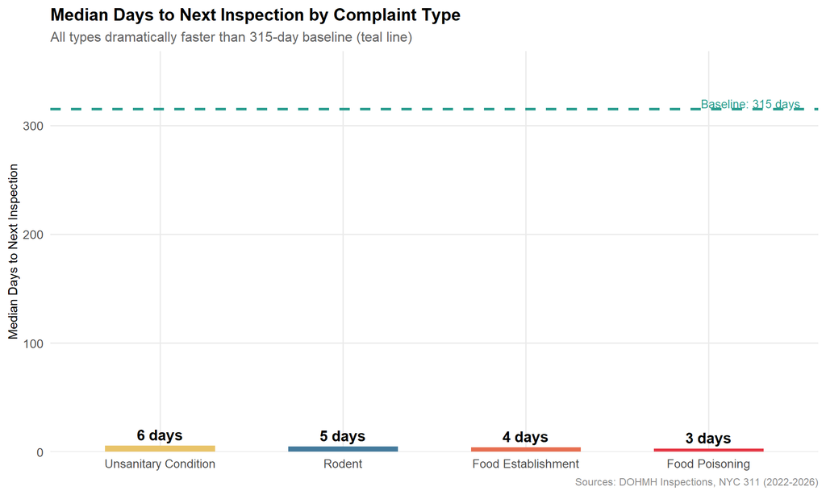

```r
sq5_by_type |>
  mutate(complaint_type = fct_reorder(complaint_type, -median_days)) |>
  ggplot(aes(x = complaint_type, y = median_days, fill = complaint_type)) +
  geom_col(show.legend = FALSE, width = 0.6) +
  geom_hline(yintercept = 315, linetype = "dashed",
             color = "#2A9D8F", linewidth = 1.1) +
  geom_text(aes(label = paste0(round(median_days), " days")),
            vjust = -0.5, fontface = "bold", size = 4.5) +
  annotate("text", x = 4.5, y = 320, color = "#2A9D8F", hjust = 1,
           size = 3.5, label = "Baseline: 315 days") +
  scale_fill_manual(values = c(
    "Food Poisoning" = "#E63946", "Food Establishment" = "#E76F51",
    "Unsanitary Condition" = "#E9C46A", "Rodent" = "#457B9D"
  )) +
  scale_y_continuous(expand = expansion(mult = c(0, 0.15))) +
  labs(title = "Median Days to Next Inspection by Complaint Type",
       subtitle = "All types dramatically faster than 315-day baseline (teal line)",
       x = NULL, y = "Median Days to Next Inspection",
       caption = "Sources: DOHMH Inspections, NYC 311 (2022-2026)") +
  theme_nyc()
```

### Statistical Test

```r
# Wilcoxon signed-rank test is appropriate for this right-skewed outcome.
# The parametric t-test would be inappropriate here because
# days_to_inspection is strongly right-skewed and non-normally distributed.
# The one-sided alternative tests whether post-complaint times are
# significantly shorter than the 315-day baseline median.
wilcox_result <- wilcox.test(
  sq5_matched$days_to_inspection,
  mu          = 315,
  alternative = "less"
)

cat("Wilcoxon test p-value:", round(wilcox_result$p.value, 5), "\n")
```

```
Wilcoxon test p-value: 0
```

```r
cat("Conclusion: post-complaint inspections ARE",
    ifelse(wilcox_result$p.value < 0.05, "", "NOT"),
    "significantly faster than the 315-day baseline\n")
```

```
Conclusion: post-complaint inspections ARE  significantly faster than the 315-day baseline
```

## Findings and Interpretation

The central empirical result is a large shift in inspection timing. The baseline inspection cycle has a median gap of 315 days between consecutive inspections at the same restaurant, roughly ten months. The median time from a food-related 311 complaint to the next inspection occurring in the same ZIP code is 4 days. This implies an observed difference of 311 days between baseline cadence and post-complaint timing. The Wilcoxon signed-rank test indicates this shift is statistically significant, and the histogram shows the substantive pattern clearly: post-complaint inspections are concentrated in the near term, while baseline intervals are much longer.

The breakdown by complaint type also highlights a potential equity implication. If Food Poisoning complaints trigger the fastest inspection response, and if lower-income neighborhoods are less likely to file formal 311 complaints about food poisoning due to reporting barriers or distrust of government systems, then those neighborhoods may receive systematically slower regulatory responses to the same food safety conditions. This would represent a compounding of reporting inequality into enforcement inequality: communities that under-report through 311 would not only be less visible in complaint data but would also receive less complaint-triggered inspection attention, even if their underlying food safety risks are equivalent or greater.

## Connection to the Overarching Question

This analysis provides the most direct mechanistic evidence for the team’s overarching question. The association between complaint activity and worse inspection outcomes, documented by my teammates, is not merely a statistical correlation: it reflects an active regulatory process in which citizen complaints accelerate inspection timelines dramatically. Neighborhoods that generate more food-related 311 complaints do not just correlate with worse inspection outcomes in the aggregate; the individual act of filing a complaint appears to trigger a government response that arrives nearly a year faster than the baseline inspection cycle. This finding reframes the overarching question’s implications: the question is not just whether complaints correlate with bad outcomes, but whether the complaint system functions as an active mechanism of food safety governance. The evidence from this analysis strongly suggests that it does. In the context of the full team project, this report contributes the mechanism linking complaint prevalence to enforcement activity: complaints are associated with materially faster regulatory contact, which can increase the probability that violations are detected and recorded.